# EIS 2026 Variable Atlas

### Whether the respondent's job is full-time or part-time

Base: Currently employed (xdemEmploy in 1:3) — n = 1,591

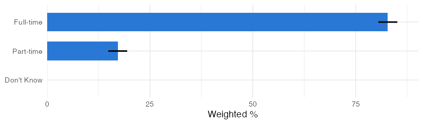

### Marital status

n = 3,144

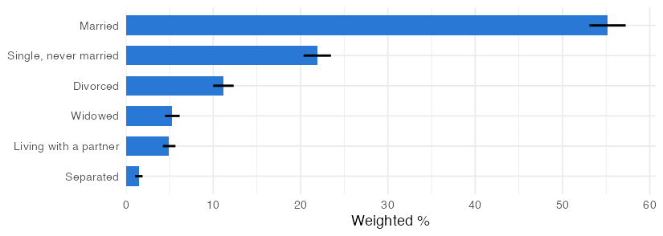

### Married

n = 3,144

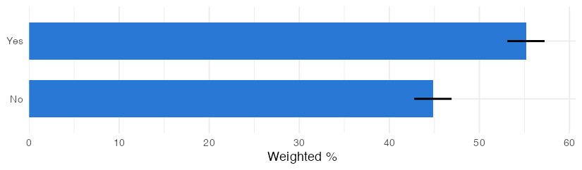

### Whether illegal noncitizen voting changes election outcomes

Base: BPC45 in 1:4 (thinks it occurs at all) — n = 2,648

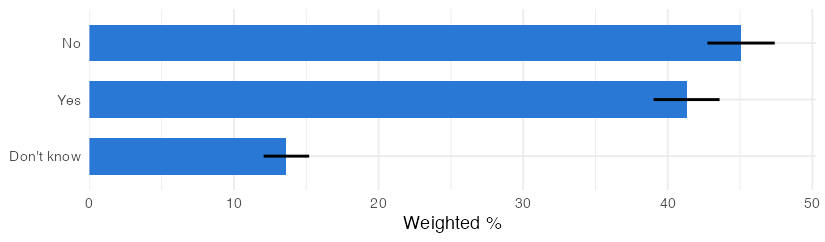

### Party identification, three categories, leaners not assigned

n = 3,144

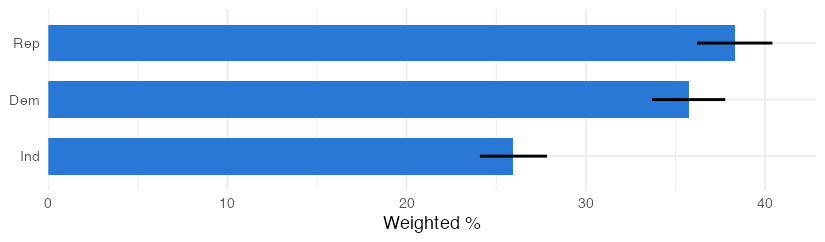

### Party identification, three categories, with leaners assigned to the party they lean toward

n = 3,144

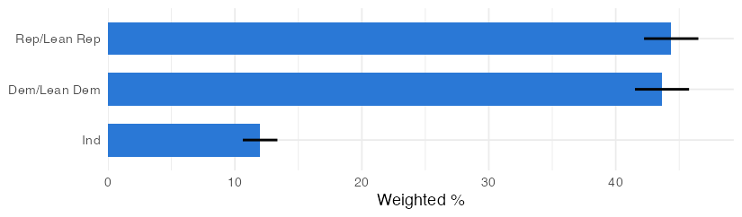

### Party identification crossed with gender

n = 3,140

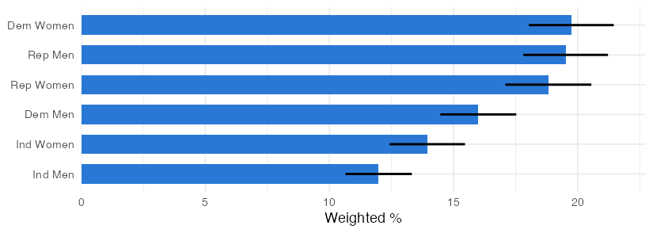

### Party an independent leans toward

Base: Independents (xpid3 = 2) — n = 840

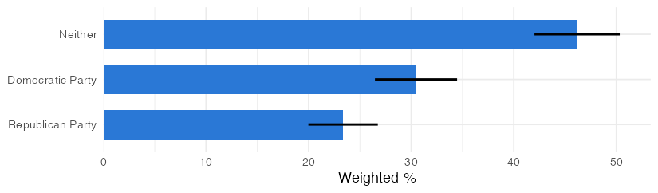

### Race and ethnicity, four mutually exclusive categories

n = 3,144

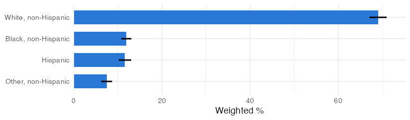

### Race, five categories

n = 3,144

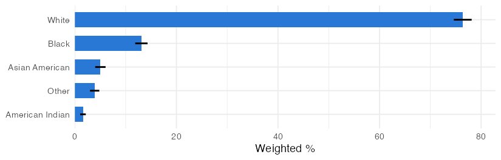

### Race: Black

n = 3,144

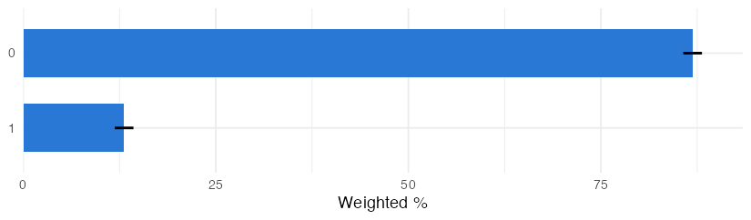

### Ethnicity: Hispanic

n = 3,144

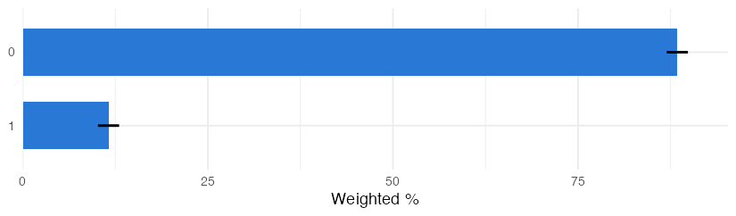

### Race: other than White, Black, or Hispanic

n = 3,144

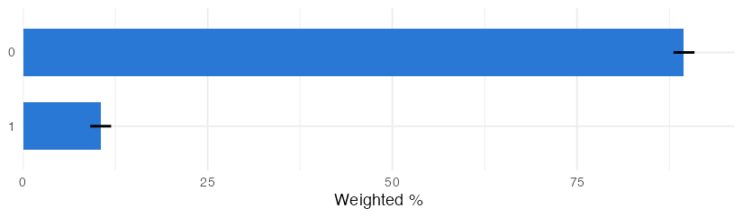

### Race: White

n = 3,144

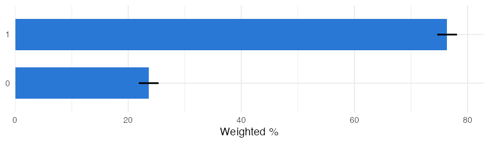

### How contacts election officials about how to register and vote

Base: BPC11_1 or BPC11_2 selected (election officials) — n = 1,026

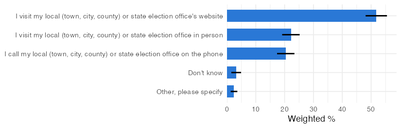

### Whether the how-to-register source question was asked about actual or hypothetical behavior

n = 3,144

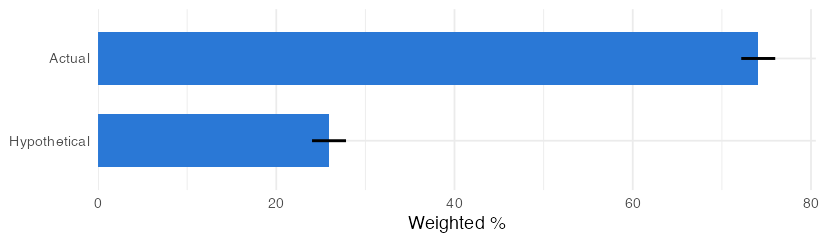

### How would contact election officials about how to register and vote

Base: BPC12_1 or BPC12_2 selected (election officials) — n = 347

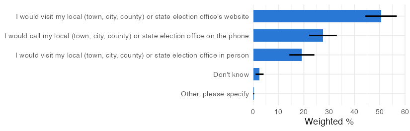

### Census region, four categories

n = 3,144

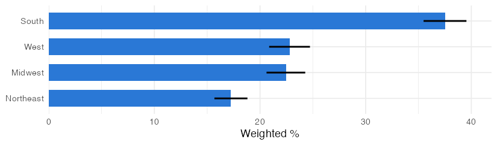

### Religious affiliation

n = 3,144

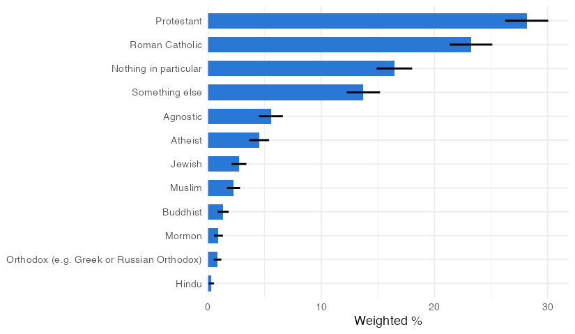

### How contacts election officials about how elections are run

Base: BPC19_1 or BPC19_2 selected (election officials) — n = 927

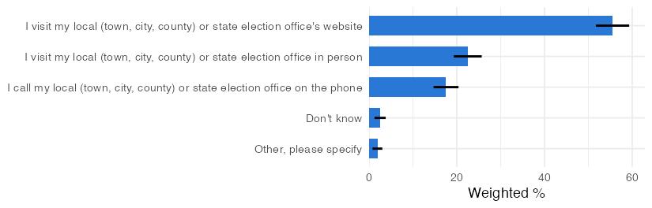

### Whether the how-elections-are-run source question was asked about actual or hypothetical behavior

n = 3,144

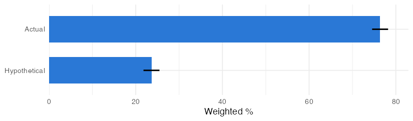

### How would contact election officials about how elections are run

Base: BPC20_1 or BPC20_2 selected (election officials) — n = 207

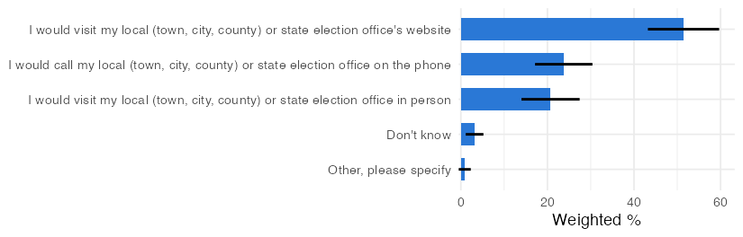

### In the registered-voter sample

n = 3,144

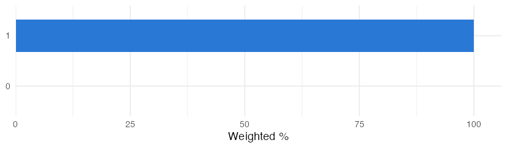

### Vendor segment: likely midterm voter

Base: Vendor segment: BPCdem3 >= 8 — n = 3,144

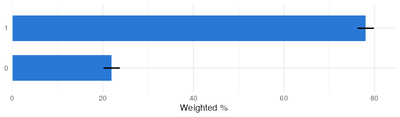

### Vendor segment: MAGA Republican

Base: Vendor segment: BPCdem1 in 1:2 — n = 3,144

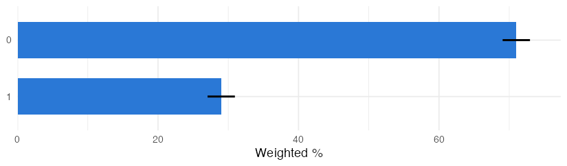

### Vendor segment: progressive Democrat

Base: Vendor segment: BPCdem2 in 1:2 — n = 3,144

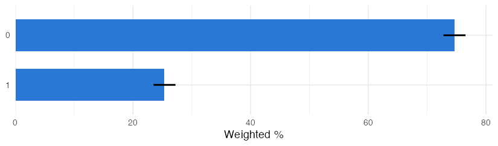

### Sexual orientation

n = 3,144

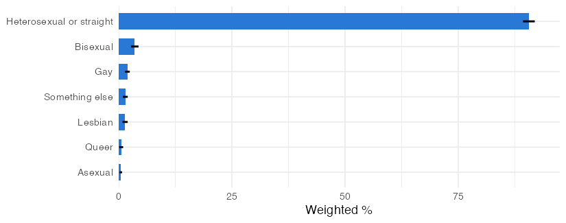

### Straightlined the AI good/bad matrix (same answer to every item)

n = 3,144

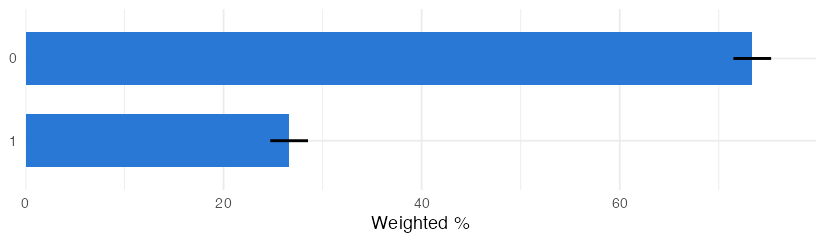

### Straightlined the election-concern matrix (same answer to every item)

n = 3,144

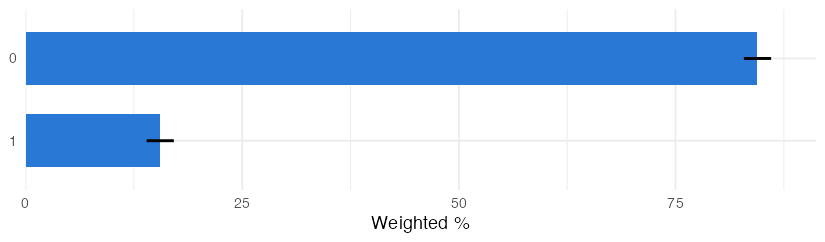

### Straightlined the information-seeking matrix (same answer to every item)

n = 3,144

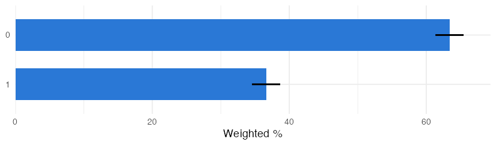

### Most important issue

n = 3,144

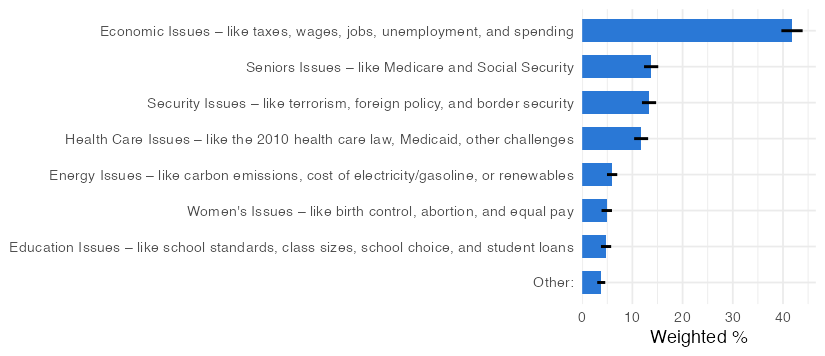

### Transgender or non-binary

n = 3,144

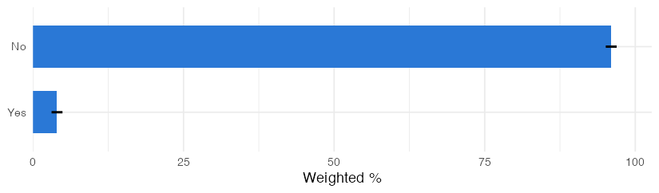

### Member of a labor union household

n = 3,144

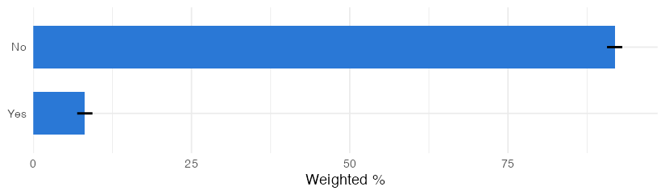

### Recalled 2024 presidential vote

n = 3,144

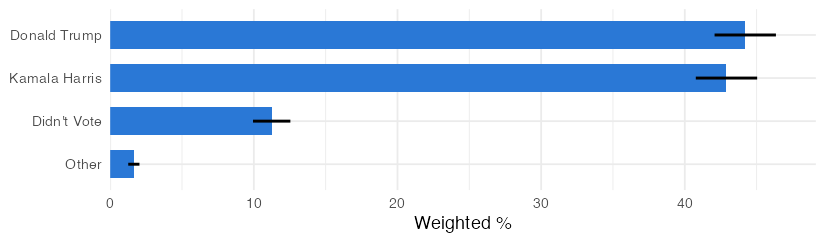

### How contacts election officials about who won an election

Base: BPC27_1 or BPC27_2 selected (election officials) — n = 760

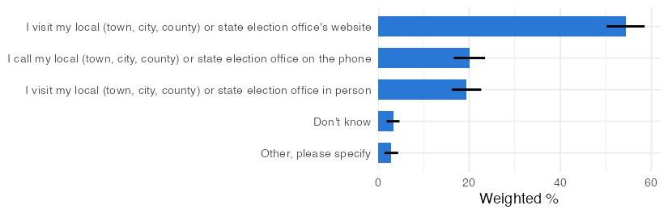

### Whether the who-won source question was asked about actual or hypothetical behavior

n = 3,144

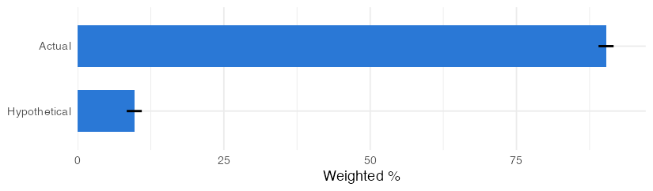

### How would contact election officials about who won an election

Base: BPC28_1 or BPC28_2 selected (election officials) — n = 37

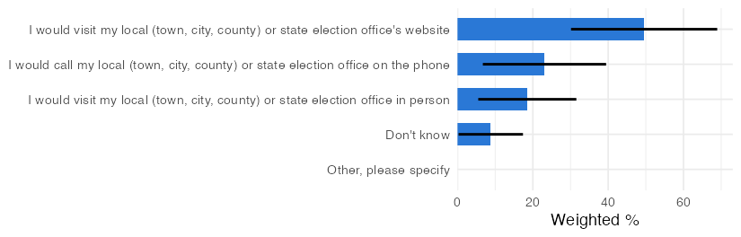

## Batteries (select-all-that-apply, and pooled indicators) (27)

### AI chatbots used for election news

Base: BPC2_11 = 1 (AI chatbot). NOTE: the delivered stem says 'select all that apply' but the questionnaire specifies SELECT UP TO 2, and the data confirms the cap of 2 was programmed — n = 173

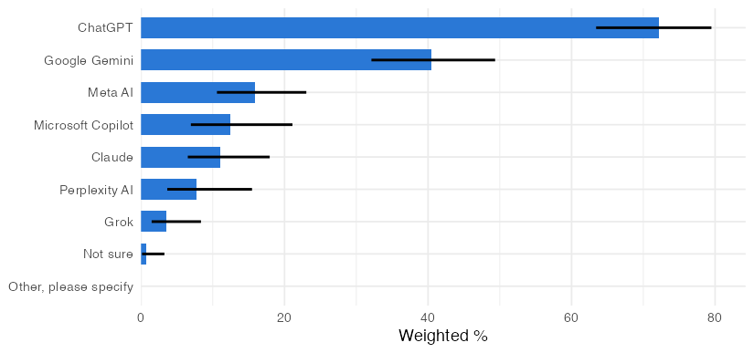

### Sources used to find information about how to register and vote

Base: BPC1_1 in 1:4 (does seek registration info) — n = 2,349

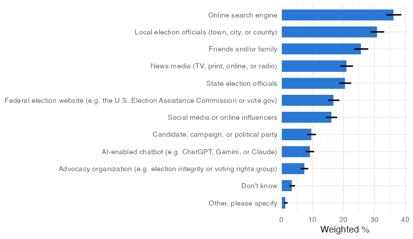

### Sources would use to find information about how to register and vote

Base: BPC1_1 = 5 (never seeks registration info) — n = 795

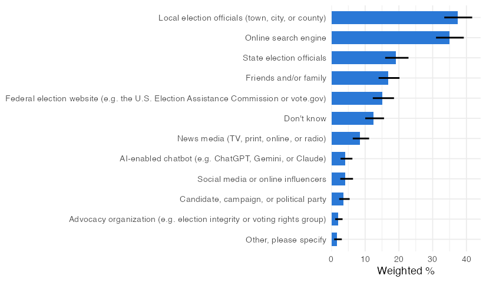

### Social media platforms used for information about how to register and vote

Base: BPC11_6 selected (social media) — n = 397

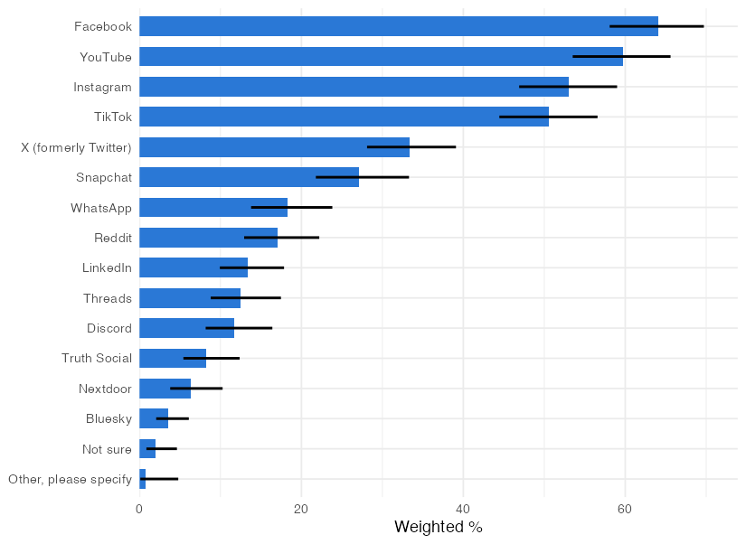

### Social media platforms would use for information about how to register and vote

Base: BPC12_6 selected (social media) — n = 38

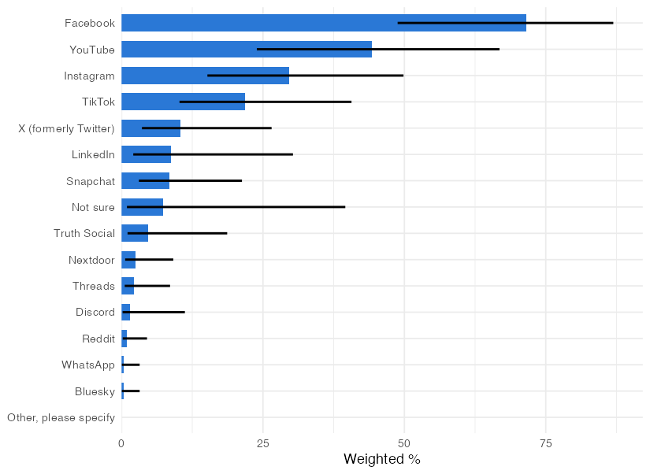

### AI chatbots used for information about how to register and vote

Base: BPC11_10 selected (AI chatbot) — n = 218

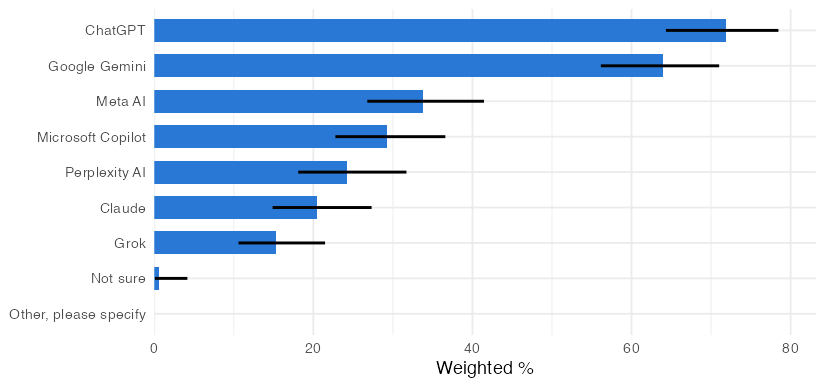

### AI chatbots would use for information about how to register and vote

Base: BPC12_10 selected (AI chatbot) — n = 33

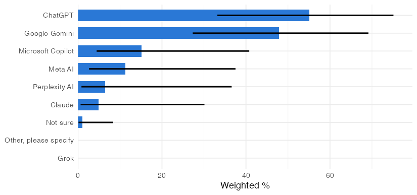

### Sources used to find information about how elections are run

Base: BPC1_2 in 1:4 (does seek election-administration info) — n = 2,401

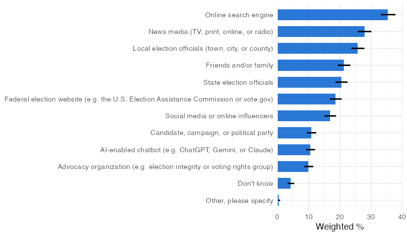

### Main sources for election news and information

n = 3,144

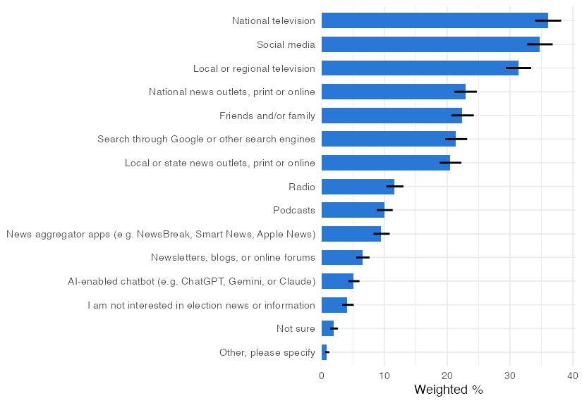

### Sources would use to find information about how elections are run

Base: BPC1_2 = 5 (never seeks election-administration info) — n = 743

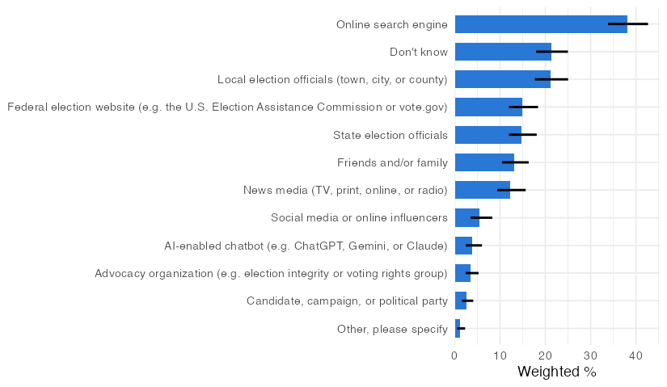

### Social media platforms used for information about how elections are run

Base: BPC19_6 selected (social media) — n = 410

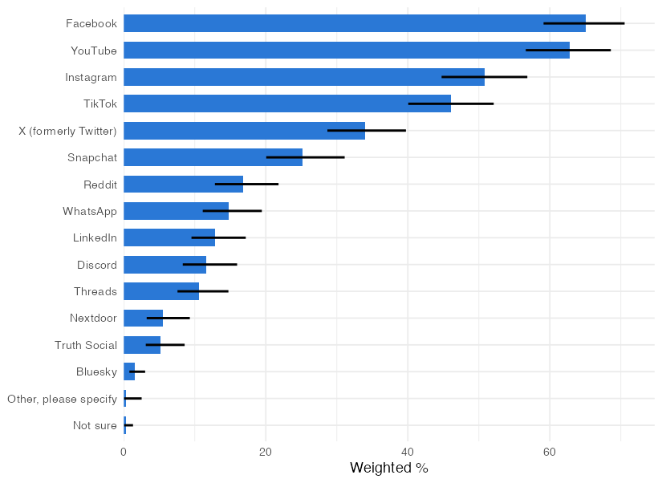

### Social media platforms would use for information about how elections are run

Base: BPC20_6 selected (social media) — n = 41

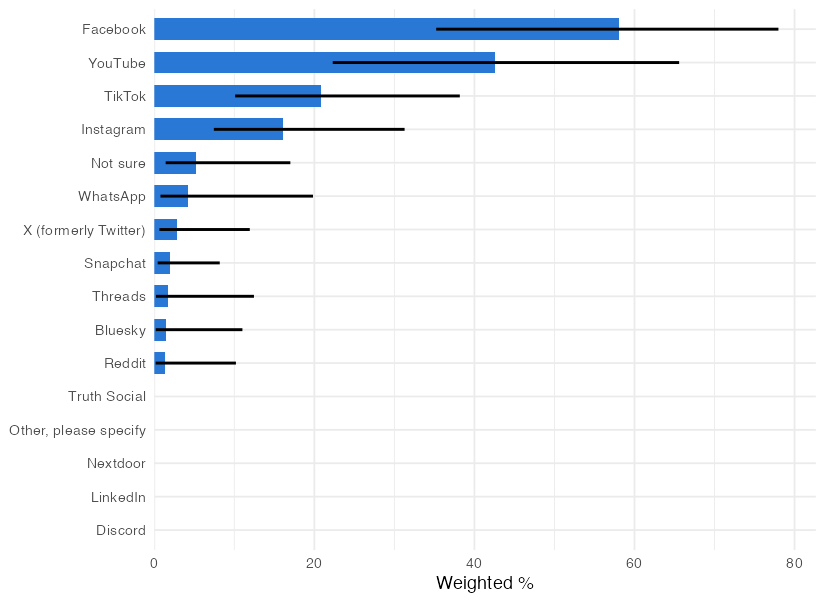

### AI chatbots used for information about how elections are run

Base: BPC19_10 selected (AI chatbot) — n = 281

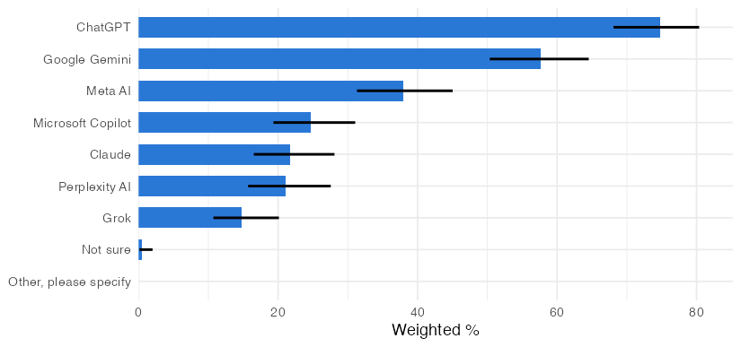

### AI chatbots would use for information about how elections are run

Base: BPC20_10 selected (AI chatbot) — n = 28

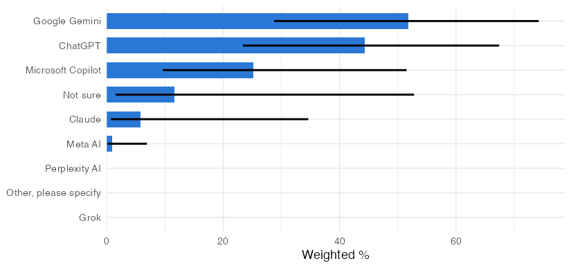

### Sources used to find information about who won an election

Base: BPC1_3 in 1:4 (does seek results info) — n = 2,813

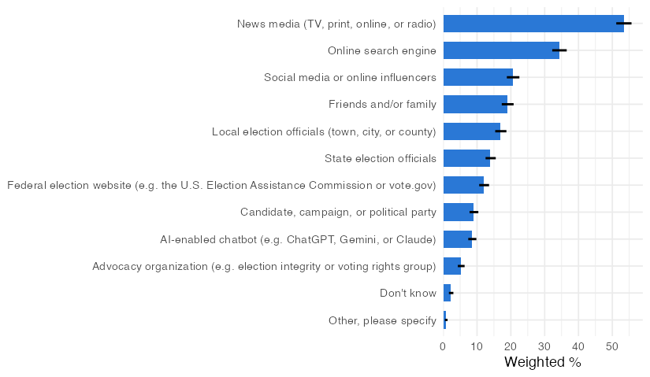

### Sources would use to find information about who won an election

Base: BPC1_3 = 5 (never seeks results info) — n = 331

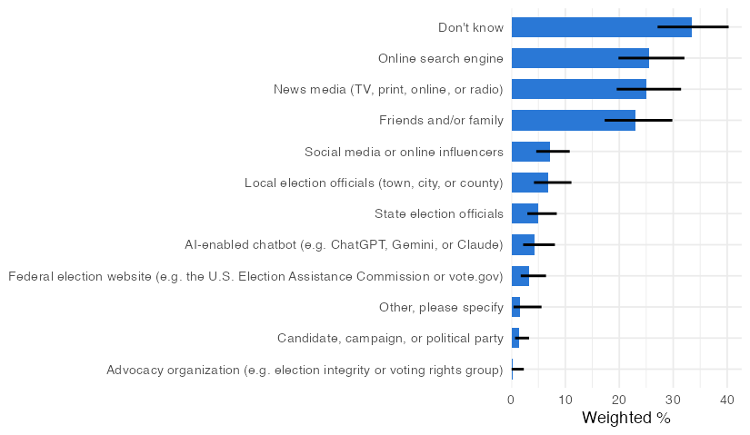